```python
import pandas as pd
from IPython.core.display import display, HTML
import matplotlib.pyplot as plt
import glob
import os
import seaborn as sns
sns.set(style='whitegrid')

%load_ext autoreload
%autoreload 1

pd.set_option('display.max_rows', 30)
pd.set_option('display.max_columns', 10)
pd.set_option('display.width', 30)
pd.set_option('display.max_colwidth', 20)

display(HTML("<style>.container { width:100% !important; }</style>"))

import warnings
warnings.filterwarnings('ignore')
```

# Data Checking and Cleaning

```python
data_files = glob.glob(os.path.join('data', "*.csv"))

data = pd.concat((pd.read_csv(f) for f in data_files), ignore_index=True)
```

```python
data.head()
```

|  | Property Type | Listing Type | Bedrooms | Bathrooms | Country Code | ... | ADR (USD) | ADR (Native) | Number Of Reservation | Revenue (USD) | Revenue (Native) |
| --- | --- | --- | --- | --- | --- | --- | --- | --- | --- | --- | --- |
| 0 | Entire home | entire_home | 2 | 2 | GB | ... | 244 | 193 | 1 | 2974 | 2349 |
| 1 | Entire rental unit | entire_home | 1 | 1 | GB | ... | 171 | 135 | 2 | 342 | 270 |
| 2 | Private room in ... | private_room | 1 | 1 | GB | ... | 73 | 58 | 2 | 312 | 246 |
| 3 | Entire townhouse | entire_home | 6 | 3 | GB | ... | 537 | 424 | 0 | 0 | 0 |
| 4 | Entire rental unit | entire_home | 1 | 2 | GB | ... | 95 | 75 | 0 | 2945 | 2327 |

5 rows × 25 columns

```python
data.info()
```

```
<class 'pandas.core.frame.DataFrame'>
RangeIndex: 34634 entries, 0 to 34633
Data columns (total 25 columns):
 #   Column                 Non-Null Count  Dtype
---  ------                 --------------  -----
 0   Property Type          34634 non-null  object
 1   Listing Type           34634 non-null  object
 2   Bedrooms               34634 non-null  object
 3   Bathrooms              34634 non-null  int64
 4   Country Code           34634 non-null  object
 5   City                   34634 non-null  object
 6   Zipcode                34568 non-null  object
 7   Latitude               34634 non-null  float64
 8   Longitude              34634 non-null  float64
 9   Currency Native        34634 non-null  object
```

[output cut: 17 more lines]

## Checking data types

It seems that 'Scraped during month' is always true, it does not give any information we can drop it.

```python
data.drop('Scraped During Month', axis=1, inplace=True)
```

Check mixed types:

```python
def check_mixed_types(column):
    return column.apply(lambda x: type(x)).nunique() > 1

# Apply the function to each column and print the result
mixed_type_columns = data.apply(check_mixed_types)
mixed_type_columns
```

[output not shown]

### Bedrooms

```python
data.loc[pd.to_numeric(data['Bedrooms'], errors='coerce').isnull(), 'Bedrooms']
```

```
77       Studio
86       Studio
113      Studio
233      Studio
299      Studio
          ...
34345    Studio
34368    Studio
34519    Studio
34527    Studio
34545    Studio
Name: Bedrooms, Length: 972, dtype: object
```

```python
all(data.loc[pd.to_numeric(data['Bedrooms'], errors='coerce').isnull(), 'Bedrooms'] == 'Studio')
```

```
True
```

We can assume that 'Studio' means 1 Bedroom:

```python
data['Bedrooms'] = pd.to_numeric(data['Bedrooms'], errors='coerce')
data['Bedrooms'].fillna(1, inplace=True)
```

### Last seen and reporting month should be datetime

```python
data['last_seen'] = pd.to_datetime(data['last_seen'])
data['Reporting Month'] = pd.to_datetime(data['Reporting Month'], format='%Y-%m')
```

## Checking the missing values

```python
missing_values = data.isnull().sum()
print(missing_values[missing_values > 0])
```

```
Zipcode            66
cleaning_fee    12194
dtype: int64
```

### Zipcodes

- We can deal with missing Zipcodes with geopy module that allow to extract a Zipcode from latitude, longitude coordinates

```python
missing_zipcodes = data.loc[data['Zipcode'].isnull()]
```

```python
import geopy
geo_locator = geopy.Nominatim(user_agent='1234')
```

```python
data.loc[data['Zipcode'].isnull(), 'Zipcode'] = missing_zipcodes.apply(lambda x: geo_locator.reverse((x['Latitude'], x['Longitude'])).raw['address'].get('postcode'), axis=1)
```

```python
missing_zipcodes = data.loc[data['Zipcode'].isnull()]
print(missing_zipcodes['Airbnb Property ID'].unique())
```

```
[50984585]
```

It seems that there is a specific listing with no available Zipcode. It's reasonable to assign it a random value.

```python
data.loc[data['Zipcode'].isnull(), 'Zipcode'] = 'BN 9999'
```

## cleaning_fee

- Looking at the distribution of cleaning_fee we can understand in what ways we can handle the missing values
  - If the distribution is normal we could use the median value
  - A smarter filling method could be using the median of the same Listing Type

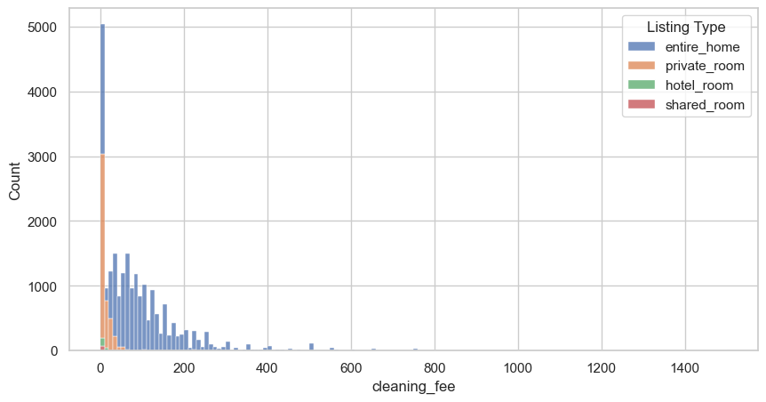

```python
f, ax = plt.subplots(1,1,figsize=(10,5))
sns.histplot(data.dropna(), ax=ax, x='cleaning_fee', hue='Listing Type', binwidth=10, multiple='stack')
```

As we can see the distribution is not quite normal, positively skewed, and it is reasonable to fill the missing values with the median value of the listing type.

```python
median_by_listing_type = data.dropna().groupby('Listing Type')['cleaning_fee'].median().to_dict()
```

```python
median_by_listing_type
```

```
{'entire_home': 80.0,
 'hotel_room': 0.0,
 'private_room': 0.0,
 'shared_room': 0.0}
```

```python
data.loc[data['cleaning_fee'].isnull(), 'cleaning_fee'] = data.loc[data['cleaning_fee'].isnull()].apply(lambda x: median_by_listing_type.get(x['Listing Type']), axis=1)
```

# Exploratory Data Analysis

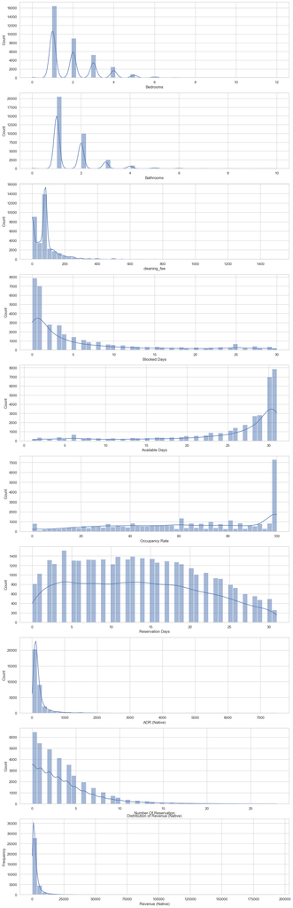

```python
# Distribution plots for numerical columns
numerical_cols = ['Bedrooms', 'Bathrooms', 'cleaning_fee', 'Blocked Days', 'Available Days', 'Occupancy Rate', 'Reservation Days', 'ADR (Native)', 'Number Of Reservation', 'Revenue (Native)']
fig, axes = plt.subplots(len(numerical_cols), 1, figsize=(15, 50))
for i, col in enumerate(numerical_cols):
    sns.histplot(data[col], ax=axes[i], bins=50, kde=True)
    plt.title(f'Distribution of {col}')
    plt.xlabel(col)
    plt.ylabel('Frequency')
plt.show()
```

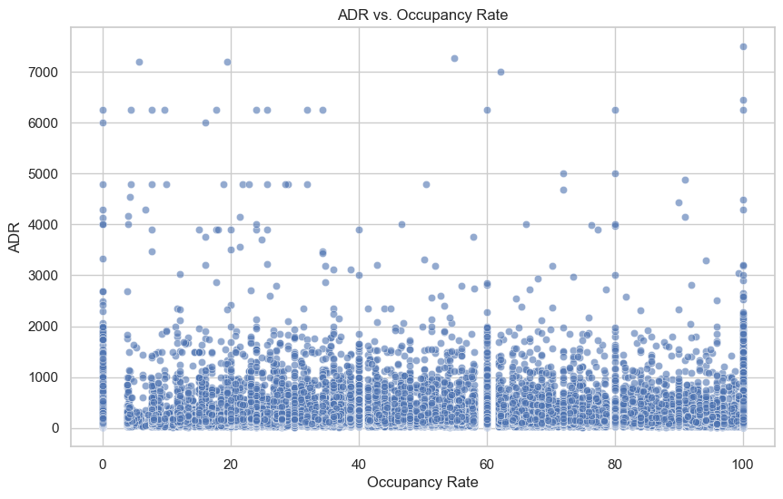

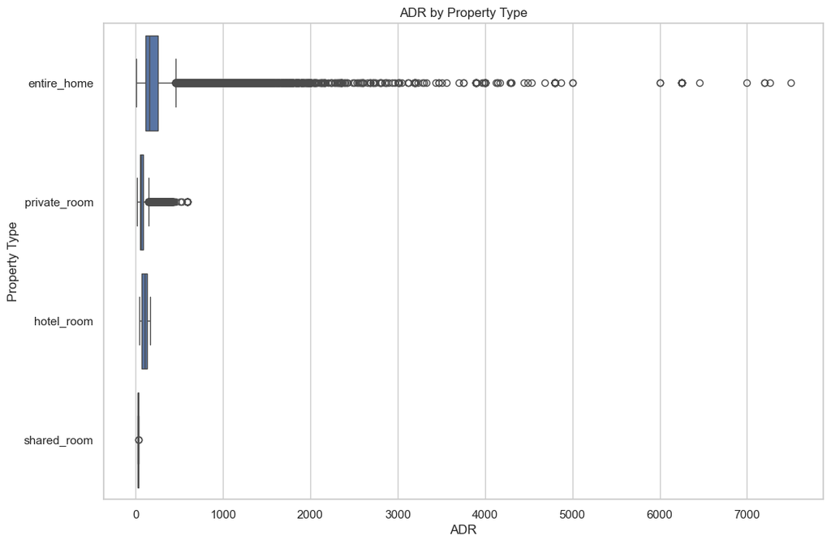

```python
plt.figure(figsize=(10, 6))
sns.scatterplot(data=data, x='Occupancy Rate', y='ADR (Native)', alpha=0.6)
plt.title('ADR vs. Occupancy Rate')
plt.xlabel('Occupancy Rate')
plt.ylabel('ADR')
plt.show()

# Plot average ADR by Property Type
plt.figure(figsize=(12, 8))
sns.boxplot(data=data, x='ADR (Native)', y='Listing Type')
plt.title('ADR by Property Type')
plt.xlabel('ADR')
plt.ylabel('Property Type')
plt.show()
```

# Summary

## ADR vs. Occupancy Rate:

- The scatter plot reveals no clear linear relationship between ADR and occupancy rate. This suggests that low ADR does not necessarily imply high occupancy rates and vice versa.

## ADR by Property Type:

The box plot shows significant variation in ADR across different property types. For instance, "Entire home" listings generally have a higher ADR compared to other property types but it also have a very high variance.

## Exploring Trends of main features

```python
months_by_listing = data.groupby('Airbnb Property ID')['Reporting Month'].agg([list, len])
```

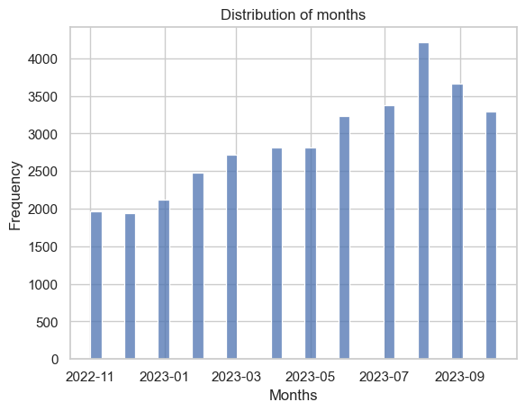

```python
sns.histplot(data['Reporting Month'])
plt.title(f'Distribution of months')
plt.xlabel('Months')
plt.ylabel('Frequency')
```

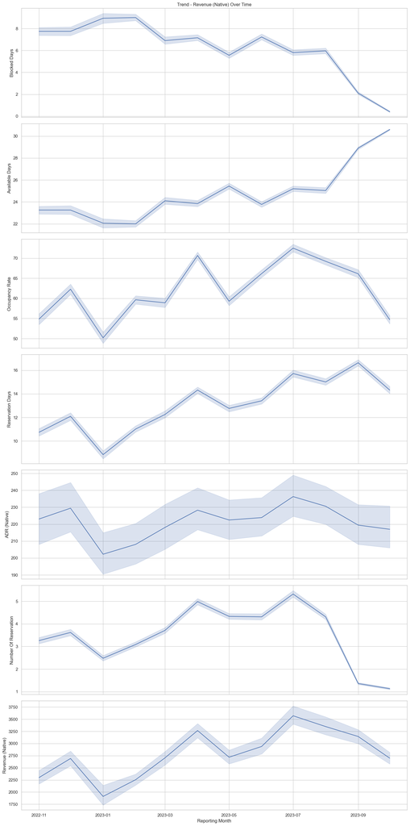

```python
import matplotlib.pyplot as plt

# Function to plot trends
to_plot_cols = ['Blocked Days',
                'Available Days',
                'Occupancy Rate',
                'Reservation Days',
                'ADR (Native)',
                'Number Of Reservation', 'Revenue (Native)']
fig, axes = plt.subplots(len(to_plot_cols), 1, figsize=(15, 30), sharex=True)
for i, col in enumerate(to_plot_cols):
    sns.lineplot(ax=axes[i], data=data, x='Reporting Month', y=col, estimator='mean')
    axes[0].set_title(f'Trend - {col} Over Time')

plt.tight_layout()
plt.show()
```

# Trends Analysis Summary

The time series plot shows trends over time for key metrics:

- ADR/Occupancy Rate/Revenue: There are fluctuations over time, with some noticeable seasonality, peaks and troughs. In particular we can observe a peak in the summertime while on average during the winter we have a low.
- Blocked days: We have almost the opposite pattern since probably during the summer the house is less blocked to favor the occupancy.

## Correlation Analysis

We can compute a correlation matrix to better understand the relation between couples of features. This can help with the next tasks.

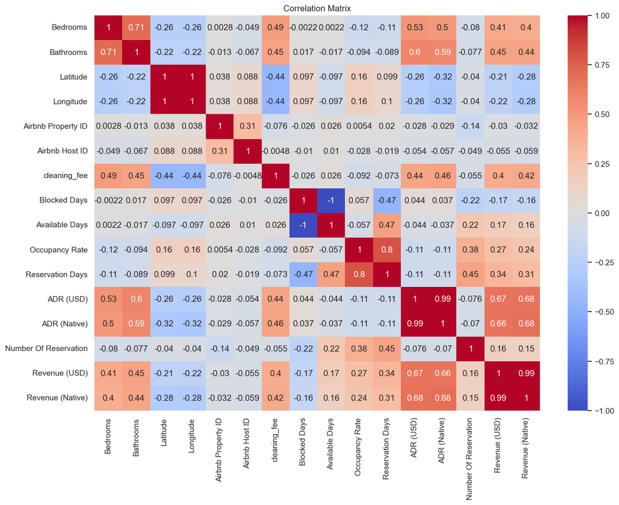

```python
cm = data.corr(numeric_only=True)
plt.figure(figsize=(14, 10))
sns.heatmap(cm, annot=True, cmap='coolwarm', vmin=-1, vmax=1)
plt.title('Correlation Matrix')
plt.show()
```

## Comments on correlation

Nothing very surprising here:

# Categorization

- Categorize by Price Range: Create categories based on ADR ranges. We expect to extract the information on how "premium" is a listing.
- Categorize by Occupancy Rate: Group listings by occupancy rate. We expect to extract the information on how popular is a listing.
- Categorize by Number of Reservations: we expect to extract the information on whether the listing is popular for short or long stays.
- Categorize by Revenue: Create categories based on Revenue ranges. We expect to extract the information on how "rich" is a listing.

```python
data['ADR (Native)'].describe()
```

```
count    34634.000000
mean       222.359098
std        340.573630
min          9.000000
25%         91.000000
50%        138.000000
75%        221.000000
max       7500.000000
Name: ADR (Native), dtype: float64
```

```python
data['Number Of Reservation'].describe()
```

```
count    34634.000000
mean         3.506381
std          3.549450
min          0.000000
25%          1.000000
50%          3.000000
75%          5.000000
max         28.000000
Name: Number Of Reservation, dtype: float64
```

```python
data['Revenue (Native)'].describe()
```

```
count     34634.000000
mean       2877.055437
std        4444.840098
min           0.000000
25%         876.000000
50%        1810.000000
75%        3298.000000
max      193560.000000
Name: Revenue (Native), dtype: float64
```

```python
bins_adr = [0,
            data['ADR (Native)'].quantile(0.2),
            data['ADR (Native)'].quantile(0.33),
            data['ADR (Native)'].quantile(0.5),
            data['ADR (Native)'].quantile(0.75),
            data['ADR (Native)'].quantile(0.90),
            float('inf')]
labels_adr = ['Very Low', 'Low', 'Medium', 'High', 'Very High', 'Premium']
data['ADR Category'] = pd.cut(data['ADR (Native)'], bins=bins_adr, labels=labels_adr, right=False)

bins_occ = [0, 20, 40, 60, 80, 100]
labels_occ = ['Very Low', 'Low', 'Medium', 'High', 'Very High']
data['Occupancy Category'] = pd.cut(data['Occupancy Rate'], bins=bins_occ, labels=labels_occ, right=False)

bins_res = [0,
            data['Number Of Reservation'].quantile(0.25),
            data['Number Of Reservation'].quantile(0.5),
            data['Number Of Reservation'].quantile(0.75),
            data['Number Of Reservation'].quantile(0.90),
            float('inf')]
labels_res = ['Very Low', 'Low', 'Medium', 'High', 'Very High']
data['Number of Reservations Category'] = pd.cut(data['Number Of Reservation'], bins=bins_res, labels=labels_res, right=False)

bins_rev = [0,
            data['Revenue (Native)'].quantile(0.2),
            data['Revenue (Native)'].quantile(0.33),
            data['Revenue (Native)'].quantile(0.5),
            data['Revenue (Native)'].quantile(0.75),
            data['Revenue (Native)'].quantile(0.9),
            float('inf')]
labels_rev = ['Very Low', 'Low', 'Medium', 'High', 'Very High', 'Premium']
data['Revenue Category'] = pd.cut(data['Revenue (Native)'], bins=bins_rev, labels=labels_rev, right=False)
```

### Visualize the distribution of the newly created categories by listing type

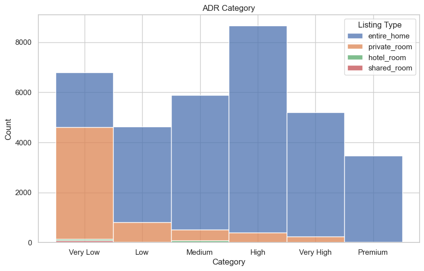

```python
plt.figure(figsize=(10, 6))
sns.histplot(data=data, x='ADR Category', hue='Listing Type', multiple='stack')
plt.title('ADR Category')
plt.xlabel('Category')
plt.ylabel('Count')
plt.show()
```

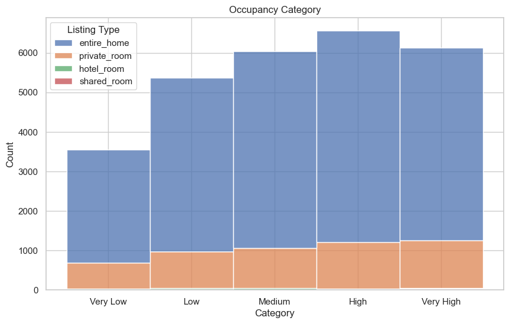

```python
plt.figure(figsize=(10, 6))
sns.histplot(data=data, x='Occupancy Category', hue='Listing Type', multiple='stack')
plt.title('Occupancy Category')
plt.xlabel('Category')
plt.ylabel('Count')
plt.show()
```

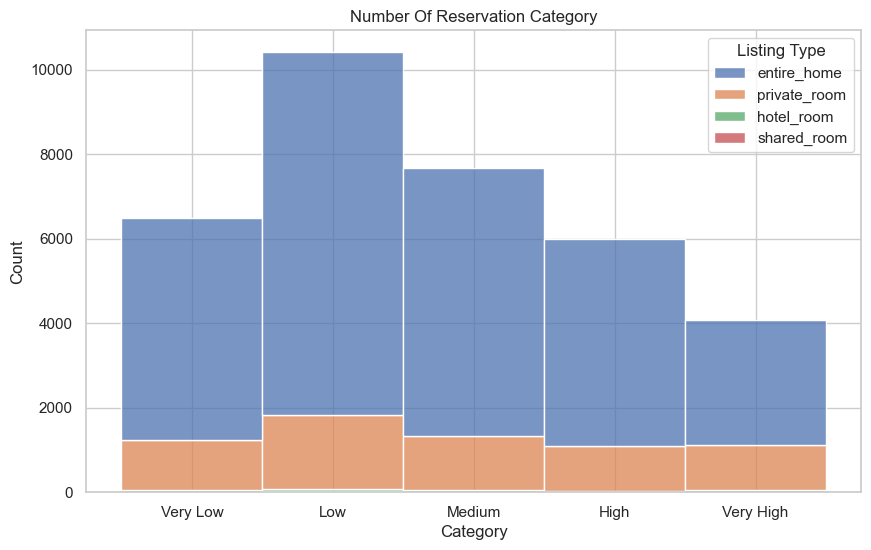

```python
plt.figure(figsize=(10, 6))
sns.histplot(data=data, x='Number of Reservations Category', hue='Listing Type', multiple='stack')
plt.title('Number Of Reservation Category')
plt.xlabel('Category')
plt.ylabel('Count')
plt.show()
```

### Categories Visualization

We can visualize the computed categories on a geographical map, to understand if there are patterns such a areas with higher ADRs or lower occupancy. Folium allows to save an interactive html map. This is more of a data science tool but I think it's reasonable to add it here. I will compute it for ADR category as an example.

```python
import folium
from folium.plugins import MarkerCluster

# Prepare data for mapping
map_data = data[['Latitude', 'Longitude', 'ADR Category']].dropna()

# Initialize the map
m = folium.Map(location=[map_data['Latitude'].mean(), map_data['Longitude'].mean()], zoom_start=12)

# Define a color map for performance categories
color_map = {'Very Low': 'red', 'Low': 'orange', 'Medium': 'yellow', 'High':'light green', 'Very High': 'green', 'Premium': 'blue'}

# Add points to the map
marker_cluster = MarkerCluster().add_to(m)
for idx, row in map_data.iterrows():
    folium.Marker(
        location=[row['Latitude'], row['Longitude']],
        popup=f"ADR: {row['ADR Category']}",
        icon=folium.Icon(color=color_map[row['ADR Category']])
    ).add_to(marker_cluster)

# Display the map
m.save('maps/airbnb_adr_map.html')
```

## Optimization Opportunities and Business Decisions

### What Airbnb can decide on:

The main revenues of Airbnb is from the fees that are applied to the listings. We can say that the more a listing is actually reserved the more money Airbnb makes. So, the direction that Airbnb would take is to increase the number of listings or improve the performance of the existing ones. After some research and speaking with some house owners I think we can list the actions that Airbnb can take as:

- Give the hosts oppurtunity to improve their business:
  - Offer a free photo shoot of their property
  - Offer the possibility to show the cut in price of the house/room
  - Boost in the search tool a specific listing
  - Give pricing advice
- To increase both the number of listings and of reservations it can start promotional campaigns

### What we can do in order to guide these decisions:

The underlying information to extract to target the correct hosts is which listings are performing well and which are not. In this way you could give personalised services to who needs them the most. For instance with this dataset we can think of a dynamic pricing tool to give to hosts that are not performing.

## Poor/Good Performers:

We can get the poor/good performers in the following way:

1. Build a similarity matrix that takes into account only the features that are not involving the current month (i.e. listing type, number of bedrooms etc.)
2. Given a listing for a span of time (if more than 1 month we aggregate the values) we compute the percentile in the desired feature (occupancy, revenue etc.) with respect to its K nearest neighbours. Choose the feature that you want to evaluate, the performance will be estimated on that feature.
3. If the percentile is lower than a threshold we can say that is poor performing and the opposite.

## Dynamic Pricing Tool:

We want to build a ML model that takes as input a listing referred to a month and outputs the revenue. In this way we can query it with multiple ADRs for the same listing to understand what is the best pricing strategy to maximize the revenue. I decide to use revenue instead of occupancy rate as output since the percentage fee that Airbnb applies is constant and it's not more important to fill the house every day rather than get more money (from Airbnb perspective). The pipeline would be:

1. Given a listing predict for a range of ADRs the expected revenue.
2. Get the best ADRs and suggest them to the owner.

# Poor/Good Performers:

Let's compute the similarity matrix first. We use information about the listing + the majority value of each category that we computed above. In this way we want to have listing closer in terms of both average cost/reservation category and size (number of beds) closer in space.

The distance metric will be a mixed distance that address mixed type arrays (both categorical and numerical).

```python
categories_to_use = [
    'Listing Type',
    'Country Code',
    'City',
    'ADR Category',
    'Occupancy Category',
    'Number of Reservations Category',
    'Revenue Category',
    'Bedrooms',
    'Bathrooms',
    'Latitude',
    'Longitude',
]
```

```python
# Group by 'Airbnb Property ID' and apply the mode function on each categorical feature that we want to use (numerical are always the same).
grouped_data = data.groupby('Airbnb Property ID').agg({x: lambda y: y.mode().max() for x in categories_to_use}).reset_index()
```

```python
grouped_data.head()
```

|  | Airbnb Property ID | Listing Type | Country Code | City | ADR Category | ... | Revenue Category | Bedrooms | Bathrooms | Latitude | Longitude |
| --- | --- | --- | --- | --- | --- | --- | --- | --- | --- | --- | --- |
| 0 | 9375 | entire_home | US | Joshua Tree | High | ... | Very Low | 1.0 | 1 | 34.10043 | -116.28544 |
| 1 | 12941 | entire_home | US | Joshua Tree | Very High | ... | Premium | 1.0 | 1 | 34.10400 | -116.31519 |
| 2 | 18994 | entire_home | US | Joshua Tree | High | ... | High | 2.0 | 1 | 34.09515 | -116.31474 |
| 3 | 32694 | entire_home | US | Joshua Tree | Very High | ... | Premium | 2.0 | 2 | 34.13271 | -116.32521 |
| 4 | 52283 | entire_home | US | Joshua Tree | Very High | ... | High | 2.0 | 1 | 34.12100 | -116.31400 |

5 rows × 12 columns

```python
import numpy as np
from sklearn.preprocessing import StandardScaler, OneHotEncoder
from scipy.spatial.distance import euclidean, hamming, pdist, squareform

# Separate numerical and categorical columns
numerical_data = grouped_data[['Bedrooms', 'Bathrooms', 'Latitude', 'Longitude']].copy()
categorical_data = grouped_data[[
    'Listing Type',
    'Country Code',
    'City',
    'ADR Category',
    'Occupancy Category',
    'Number of Reservations Category',
    'Revenue Category',
]].copy()

# Normalize numerical features
scaler = StandardScaler()
numerical_data_normalized = scaler.fit_transform(numerical_data)

# One-hot encode categorical features
encoder = OneHotEncoder(sparse=False)
categorical_data_encoded = encoder.fit_transform(categorical_data)

# Combine normalized numerical and encoded categorical features
combined_data = np.hstack((numerical_data_normalized, categorical_data_encoded))
```

```python
from functools import partial

# Function to compute mixed distance
def mixed_distance(v1, v2, num_features):
    # Separate numerical and categorical parts
    num_v1, cat_v1 = v1[:num_features], v1[num_features:]
    num_v2, cat_v2 = v2[:num_features], v2[num_features:]

    # Compute distances
    num_dist = euclidean(num_v1, num_v2)
    cat_dist = hamming(cat_v1, cat_v2)

    # Combine distances
    return num_dist + cat_dist

dist_matrix = squareform(pdist(combined_data, metric=partial(mixed_distance, num_features=numerical_data.shape[1])))
```

Set the diagonal to infinite so it does not get chosen by KNN

```python
np.fill_diagonal(dist_matrix, np.inf)
```

```python
dist_matrix.shape
```

```
(5206, 5206)
```

### Create a mapping and inverse mapping between actual Airbnb Property ID and index in the distance matrix

```python
listing_to_idx_mapping = {x['Airbnb Property ID']: idx for idx, x in grouped_data.iterrows()}
```

```python
index_to_listing_map = {idx: x['Airbnb Property ID'] for idx, x in grouped_data.iterrows()}
```

## PoorPerformerClassifier

```python
from sklearn.base import BaseEstimator, ClassifierMixin

class PoorPerformerClassifier(BaseEstimator, ClassifierMixin):
    def __init__(self, distance_matrix, revenue_data, idx_to_listing_mapping, listing_to_idx_mapping, k=5, threshold=0.75):
        self.distance_matrix = distance_matrix
        self.revenue_data = revenue_data
        self.idx_to_listing_mapping = idx_to_listing_mapping
        self.listing_to_idx_mapping = listing_to_idx_mapping
        self.k = k
        self.threshold = threshold

    def fit(self, X, y=None):
        return self

    def _get_neighbors(self, listing_index):
        # Get indices of K nearest neighbors
        distances = self.distance_matrix[self.listing_to_idx_mapping[listing_index]]
        neighbors_idx = np.argsort(distances)[:self.k]
        return neighbors_idx

    def _get_data(self, listings_idx, temporal_span):
        start_datetime = pd.to_datetime(temporal_span[0], format='%m-%Y')
        end_datetime = pd.to_datetime(temporal_span[1], format='%m-%Y')

        filtered_data = self.revenue_data.loc[
            (self.revenue_data['Airbnb Property ID'].isin(listings_idx)) &
            (self.revenue_data['Reporting Month'] >= start_datetime) &
            (self.revenue_data['Reporting Month'] <= end_datetime)
        , 'Revenue (Native)']
        return filtered_data

    def predict(self, X, raw=False, threshold=None):
        if threshold is None:
            threshold = self.threshold
        results = []
        for listing_index, temporal_span in X:
            neighbors_idx = self._get_neighbors(listing_index)
            neighbors_revenue = self._get_data([self.idx_to_listing_mapping[x] for x in neighbors_idx], temporal_span).mean()
            listing_revenue = self._get_data([listing_index], temporal_span).mean()
            if raw is True:
                results.append(neighbors_revenue - listing_revenue)
            else:
                if listing_revenue < self.threshold * neighbors_revenue:
                    results.append(1)
                else:
                    results.append(0)
        return np.array(results)
```

```python
# Create the model
model = PoorPerformerClassifier(
    distance_matrix=dist_matrix,
    revenue_data=data,
    idx_to_listing_mapping=index_to_listing_map,
    listing_to_idx_mapping=listing_to_idx_mapping,
    k=5,
    threshold=0.75
)
```

```python
X_test_poor_perf = [
    (idx, ('11-2022', '03-2023')) for idx in data['Airbnb Property ID'].unique()[:500]
]
```

```python
predictions_poor_perf = model.predict(X_test_poor_perf, 0.85)
```

```python
predictions_poor_perf[:10]
```

```
array([0, 0, 1, 0, 0, 0, 0, 0, 1, 0])
```

## Dynamic Pricing Tool:

- We want to build a model that predicts the best ADR given a listing in a specific month.
- In order to do that we will first build a model that predict the revenue, than we will query it with a range of ADRs to understand what is the best value.
- The pipeline is first building new features based on the date (season, month, day of the week), than it scales the numerical features and one hot encodes the categorical ones.

```python
from sklearn.base import BaseEstimator, TransformerMixin
from sklearn.model_selection import train_test_split
from sklearn.preprocessing import OneHotEncoder, StandardScaler, FunctionTransformer
from sklearn.ensemble import RandomForestRegressor
from sklearn.pipeline import Pipeline
from sklearn.compose import ColumnTransformer
from sklearn.metrics import mean_absolute_error, mean_squared_error, r2_score
import matplotlib.pyplot as plt

class DateFeatureExtractor(BaseEstimator, TransformerMixin):
    def __init__(self):
        pass

    def fit(self, X, y=None):
        return self

    def transform(self, X):
        X = X.copy()
        X['Month'] = X['Reporting Month'].dt.month
        X['DayOfWeek'] = X['Reporting Month'].dt.dayofweek
        # Optional: Create additional seasonal features, e.g., holidays or events
        # For simplicity, let's create a dummy season column (e.g., peak season vs. off-peak)
        # This could be tweaked for different cities etc.
        X['Season'] = X['Month'].apply(lambda x: 'Peak' if x in [6, 7, 8, 12] else 'Off-Peak')
        X.drop('Reporting Month', axis=1, inplace=True)
        return X


# Filter relevant features
relevant_features = [
    'Property Type', 'Listing Type', 'Bedrooms', 'Bathrooms', 'City',
    'Zipcode', 'Latitude', 'Longitude', 'ADR (Native)', 'Reporting Month', 'Revenue (Native)',
]
data_filt = data[relevant_features].copy()
data_filt['Zipcode'] = data_filt['Zipcode'].astype(str)
data_filt.dropna(inplace=True)

# Define features and target variable
X_data = data_filt.drop('Revenue (Native)', axis=1)
y_data = data_filt['Revenue (Native)']

# Preprocessing for numerical and categorical features
numerical_features = ['Bathrooms', 'Latitude', 'Longitude', 'ADR (Native)', 'Bedrooms']
categorical_features = ['Property Type', 'Listing Type', 'City', 'Zipcode', 'Season', 'Month', 'DayOfWeek']


# Preprocessing pipelines for numerical and categorical data
numerical_transformer = Pipeline(steps=[
    ('scaler', StandardScaler())
])

categorical_transformer = Pipeline(steps=[
    ('onehot', OneHotEncoder(handle_unknown='ignore'))
])

# Combine preprocessing steps
preprocessor = ColumnTransformer(
    transformers=[
        ('num', numerical_transformer, numerical_features),
        ('cat', categorical_transformer, categorical_features)
    ])

# Define the model pipeline
model = Pipeline(steps=[
    ('add_date_cols', DateFeatureExtractor()),
    ('preprocessor', preprocessor),
    ('regressor', RandomForestRegressor(n_estimators=100, random_state=42))
])

# Split the data into training and test sets
X_train, X_test, y_train, y_test = train_test_split(X_data, y_data, test_size=0.2, random_state=42)

# Train the model
model.fit(X_train, y_train)
```

```
Pipeline(steps=[('add_date_cols', DateFeatureExtractor()),
                ('preprocessor',
                 ColumnTransformer(transformers=[('num',
                                                  Pipeline(steps=[('scaler',
                                                                   StandardScaler())]),
                                                  ['Bathrooms', 'Latitude',
                                                   'Longitude', 'ADR (Native)',
                                                   'Bedrooms']),
                                                 ('cat',
                                                  Pipeline(steps=[('onehot',
                                                                   OneHotEncoder(handle_unknown='ignore'))]),
                                                  ['Property Type',
                                                   'Listing Type', 'City',
                                                   'Zipcode', 'Season', 'Month',
                                                   'DayOfWeek'])])),
                ('regressor', RandomForestRegressor(random_state=42))])
```

```
Mean Absolute Error: 1288.4782029074177
Mean Squared Error: 6010015.014448011
Root Mean Squared Error: 2451.533196684885
R² Score: 0.6400111028834085
```

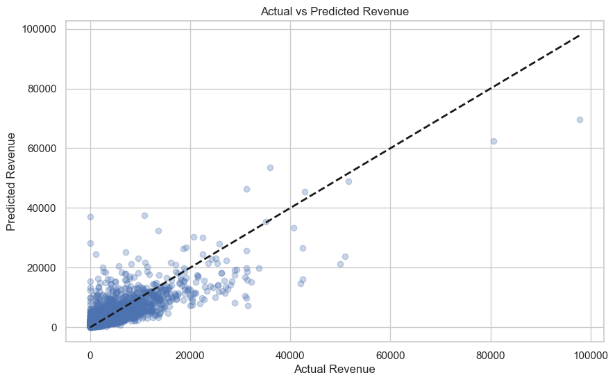

```python
# Predict on the test set
y_pred = model.predict(X_test)

# Evaluate the model
mae = mean_absolute_error(y_test, y_pred)
mse = mean_squared_error(y_test, y_pred)
rmse = np.sqrt(mse)
r2 = r2_score(y_test, y_pred)

print(f'Mean Absolute Error: {mae}')
print(f'Mean Squared Error: {mse}')
print(f'Root Mean Squared Error: {rmse}')
print(f'R² Score: {r2}')

# Plot predicted vs actual values
plt.figure(figsize=(10, 6))
plt.scatter(y_test, y_pred, alpha=0.3)
plt.plot([y_test.min(), y_test.max()], [y_test.min(), y_test.max()], 'k--', lw=2)
plt.xlabel('Actual Revenue')
plt.ylabel('Predicted Revenue')
plt.title('Actual vs Predicted Revenue')
plt.show()
```

### Method to find the best ADR

- Given the model, a listing (one row of the original dataset) and an ADR range this method computes the best ADR to maximise the revenues.

```python
# Predict function to find the best ADR
def find_best_adr(model, listing_data, adr_range):
    best_adr = None
    best_revenue = -np.inf

    for adr in adr_range:
        listing_data['ADR (Native)'] = adr
        predicted_revenue = model.predict(pd.DataFrame([listing_data]))[0]
        if predicted_revenue > best_revenue:
            best_revenue = predicted_revenue
            best_adr = adr

    return best_adr, best_revenue
```

### Example of usage

- Let's take the first poor performer to get it's best ADR for the next month

```python
# Example usage
# Select a specific listing
listing_id = X_test_poor_perf[2][0]

# Extract the specific listing data and set the desired month
listing_data = data.loc[(data['Airbnb Property ID'] == listing_id) & (data['Reporting Month'] == pd.to_datetime('2023-10-01'))].iloc[0].copy()
current_adr = listing_data['ADR (Native)']
# listing_data['Reporting Month'] = pd.to_datetime('2023-10-01')

# Define the range of ADR values to test, as example we can use from 0 to 2 times the current ADR
adr_range = np.arange(0, (current_adr * 2) // 100 * 100, 10)  # Adjust the range and step as needed

# Find the best ADR
best_adr, best_revenue = find_best_adr(model, listing_data, adr_range)

print(f"Current ADR: {current_adr} Best ADR: {best_adr}, Expected Revenue: {best_revenue}")
```

```
Current ADR: 58 Best ADR: 50, Expected Revenue: 654.05
```

# Ongoing Analytic Product

To productionize an ongoing analytic product using the Airbnb dataset, we need to consider the end goal, deployment strategy, and data requirements. Here's a detailed description of the steps involved:

## a. Data Product and Objective

### Data Product: Revenue Optimization

### Objective:

The primary aim of this data product is to help Airbnb to let property owners optimize their pricing strategies to maximize revenues. This involves:

- **Performance Monitoring**: Providing insights and alerts about underperforming listings compared to similar properties. This allows to target the owners that are not performing well or to praise the ones that are performing extraordinarily.
- **Revenue Forecasting**: Predicting future revenue based on historical data, seasonal trends, and market conditions (the model that we developed is a starting point).
- **Pricing Strategy Optimization**: Recommending optimal ADR (Average Daily Rate) to maximize revenue (the concept model that we developed is a starting point).

### Experience:

A user of this tool would be able to see all the analytics at a glance with a dedicated dashboard (see below).

### 1. Deployment Strategy

- **Model Development and Validation**: The first step is to develop one or more models similar to the ones that we developed above. The pipeline is a classic ML pipeline.
- **Data Preprocessing**: Clean and preprocess the data, handling missing values and transforming features.
- **Feature Engineering**: Create relevant features, including temporal features (month, year, season), property characteristics, and historical performance metrics.
- **Model Training**: Use machine learning models to predict revenue based on ADR and other features.
- **Model Validation**: Validate the model using cross-validation techniques and performance metrics. The second step is to keep this model updated. In order to do that we need a data pipeline able to store new meaningful data. This data will be used to retrain the model:

### 2. Building the Analytics Pipeline

- **Data Ingestion**: Set up a pipeline to continuously ingest data from Airbnb and other relevant sources (e.g., market trends, local events).
- **Feature Extraction**: Automate feature extraction and transformation using custom transformers in a data pipeline.
- **Model Training and Update**: Regularly retrain the model with new data to ensure it stays accurate and relevant.

### 3. Deployment

- **API Deployment**: Deploy the model as a RESTful API using frameworks like Flask or FastAPI. This API can take input parameters (listing details, ADR) and return revenue predictions and pricing recommendations. These APIs will be used by the dashboard or other services such as tools directly inserted into Airbnb.
- **Containerization**: Use Docker to containerize the API for consistent deployment across different environments.
- **Orchestration**: Use Kubernetes or similar orchestration tools to manage, scale, and monitor the deployed containers.

### 4. Monitoring and Maintenance

- **Performance Monitoring**: Continuously monitor the model’s performance using tools like Prometheus and Grafana.
- **Error Handling and Alerts**: Implement error handling and set up alerts for data pipeline failures or model performance degradation.
- **Regular Updates**: Schedule regular updates to the model and retrain it with new data to adapt to market changes.

## c. Data Feeding into the Product

### 1. Airbnb Listings Data

- Historical data on listings, including property characteristics (type, number of bedrooms, bathrooms, location), historical ADR, and monthly revenue.

### 2. Temporal Data

- Date-related features such as month, year, and day of the week.
- Seasonal indicators (e.g., peak season, off-peak season).

### 3. External Market Data

- Market trends and competitor pricing data to understand the broader market context.
- Local events and holidays that can impact demand and pricing.

### 4. Real-time Data

- Real-time booking data to provide up-to-date insights and recommendations.
- Feedback loop data from users (property owners/managers) to refine and improve recommendations.

### Steps Summary:

1. **Data Collection and Preprocessing**:
   - Ingest and preprocess historical and real-time data.
   - Extract and transform features relevant to revenue forecasting and pricing optimization.
2. **Model Development**:
   - Train machine learning models to predict revenue and recommend optimal ADR.
   - Validate and refine the models using cross-validation and performance metrics.
3. **API Deployment**:
   - Deploy the trained model as an API for real-time predictions and recommendations.
   - Use containerization and orchestration tools for scalable and reliable deployment.
4. **Monitoring and Maintenance**:
   - Monitor model performance and data pipeline health.
   - Schedule regular updates and retraining of the model to keep it accurate and relevant.

## d. Dynamic Dashboard for Visualization

### Objective:

To provide a user-friendly interface for property owners and managers to visualize key metrics, predictions, and recommendations. The dashboard will offer real-time insights and help users make data-driven decisions to optimize their listings' performance.

### Features of the Dashboard:

1. **Revenue Forecasting**:
   - Display predicted revenues for upcoming months based on current ADR and other features.
   - Visualize historical revenue trends and compare with predictions.
2. **Pricing Strategy Optimization**:
   - Show the optimal ADR recommendations to maximize revenue.
   - Allow users to simulate different ADR scenarios and see the projected revenue impact.
3. **Performance Monitoring**:
   - Provide performance metrics and comparisons against similar listings.
   - Highlight underperforming listings and suggest actionable insights.
4. **Real-time Updates**:
   - Integrate real-time booking data to provide up-to-date insights.
   - Display alerts and notifications for significant changes or opportunities.

### Tools and Technologies:

- **Dashboard Framework**: Use tools like Tableau, Power BI, or custom solutions with Dash/Plotly.
- **Data Integration**: Connect the dashboard to the data pipeline and API for real-time data updates.
- **User Interface**: Design an intuitive and interactive UI for easy navigation and decision-making.

### Deployment:

- Host the dashboard on a web server (e.g., AWS, Azure) for accessible online access.
- Ensure security and authentication to protect sensitive data.
- Implement monitoring and logging to track dashboard performance and usage.

This structured approach ensures that the analytic product remains effective, accurate, and scalable, providing valuable insights and recommendations for revenue optimization in the Airbnb market.